# Supplementary Material for Goodness-of-Fit Checks for Joint Models

### 1.11.3 Variance Function

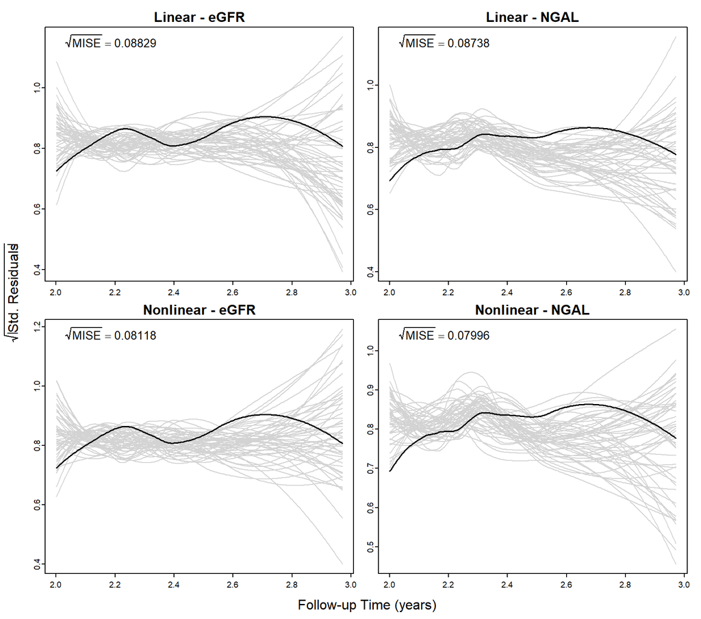

### 1.11.4 Correlation Structure

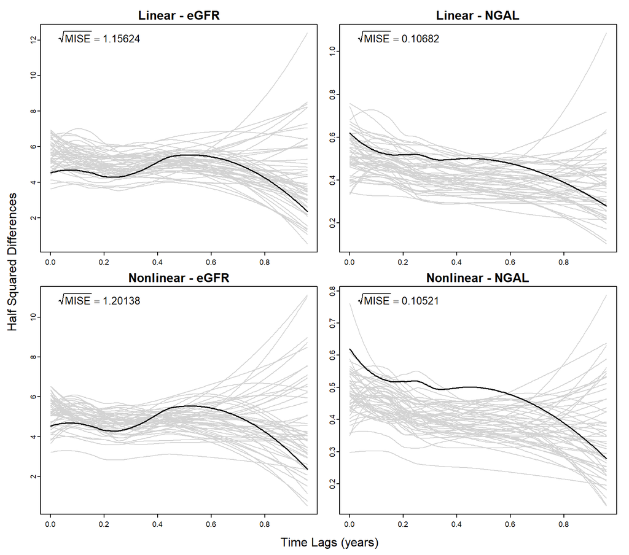

## 1.12 Longitudinal Models: Individualized Posterior-Posterior Checks

- Mean function for the two longitudinal outcomes and Patients 180 and 124 based on the two fitted joint models using the current value functional form. The results from the area/integral functional form were very similar. The asterisks denote the observed data points.
- Patient 124 experienced the composite endpoint, whereas Patient 180 did not.
- In each figure, we compare the observed data metric (black line) with the same metric calculated in 50 simulated datasets from the corresponding model (grey lines).

### 1.12.1 Patient 180

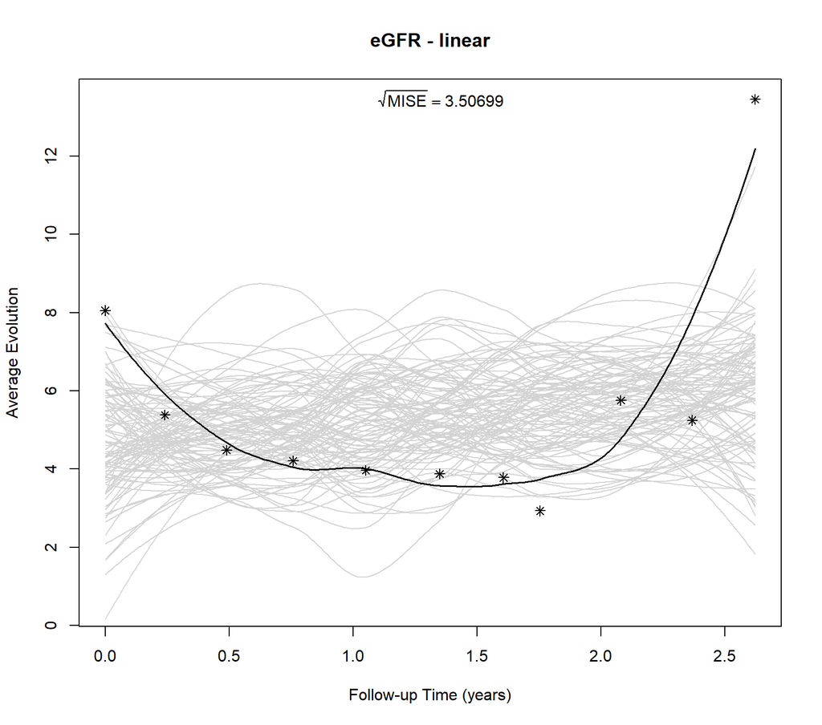

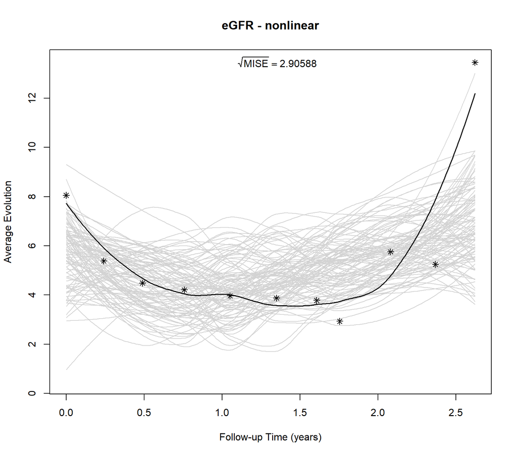

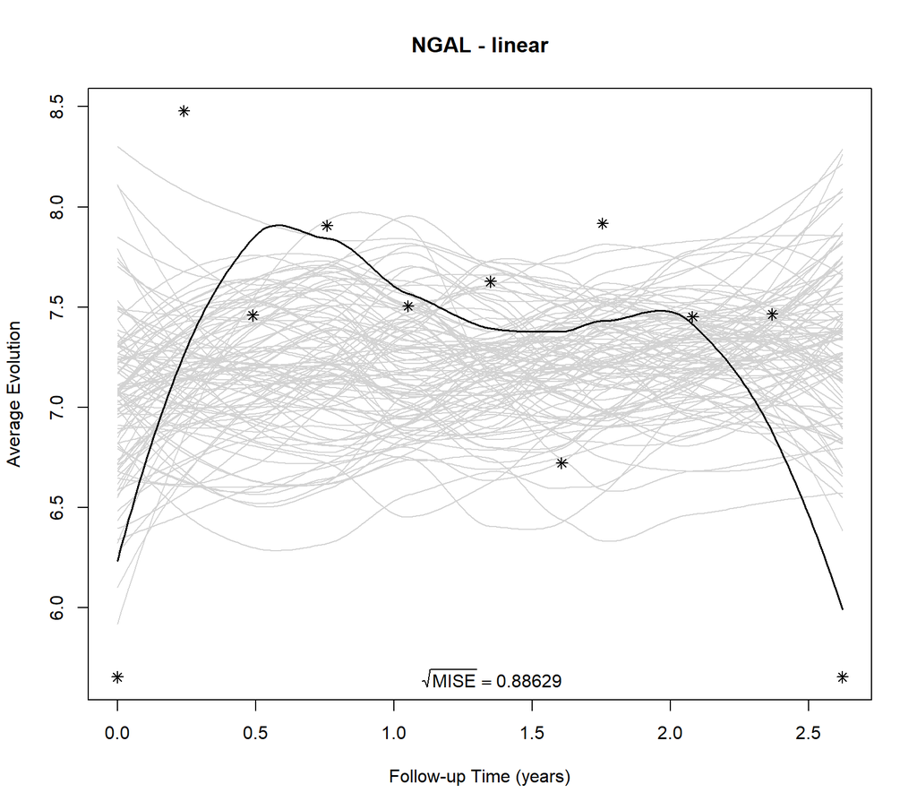

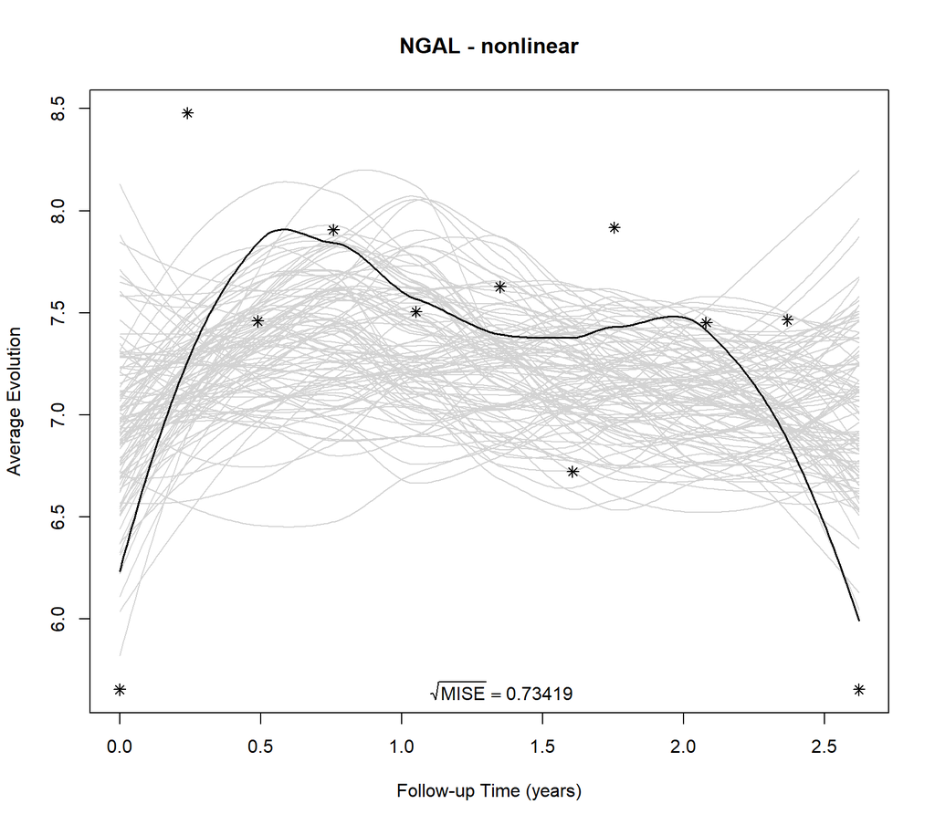

### 1.12.2 Patient 124

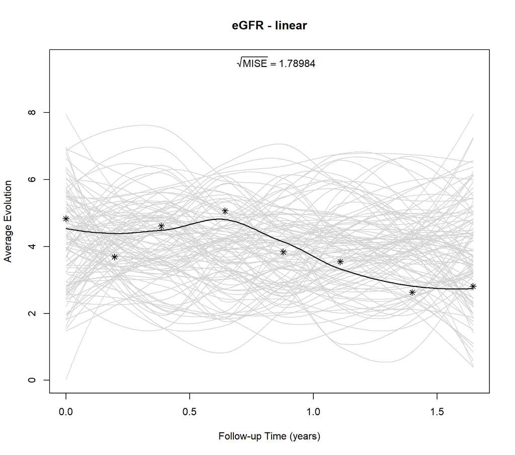

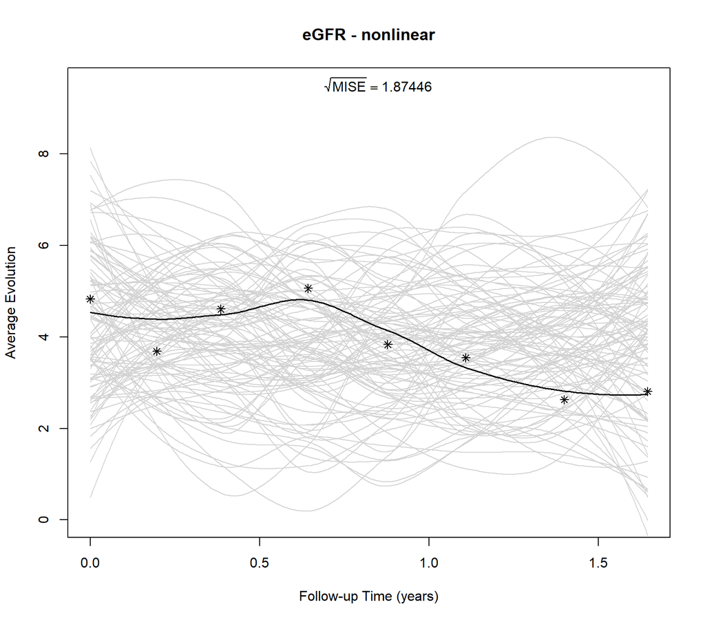

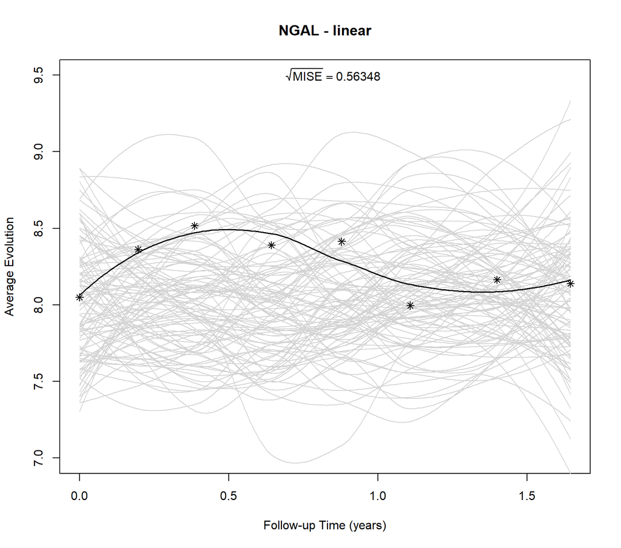

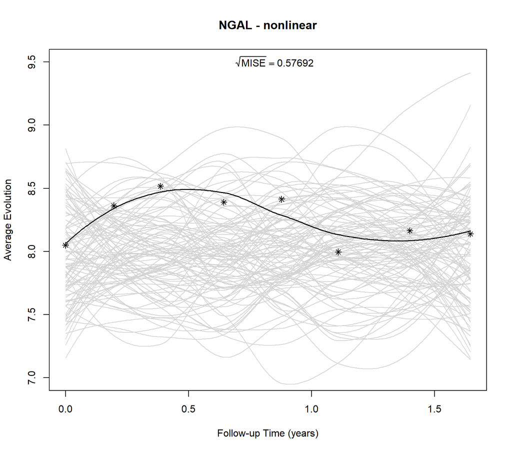

## 1.13 Event Time Model: Posterior-Posterior Checks

- The two tabs show the empirical cumulative distribution function and the probability integral transform of the subject-specific cumulative distribution functions for the four fitted joint models.
- In the title of each figure, ‘Linear/Nonlinear’ refers to the specification of the linear mixed models (i.e., linear time trends or splines in both the fixed- and random-effects), and ‘Value/Area’ refers to the functional form (i.e., current value or integral/area).
- In each figure, we compare the observed data metric (black line) with the same metric calculated in 50 simulated datasets from the corresponding model (grey lines).

### 1.13.1 ECDF

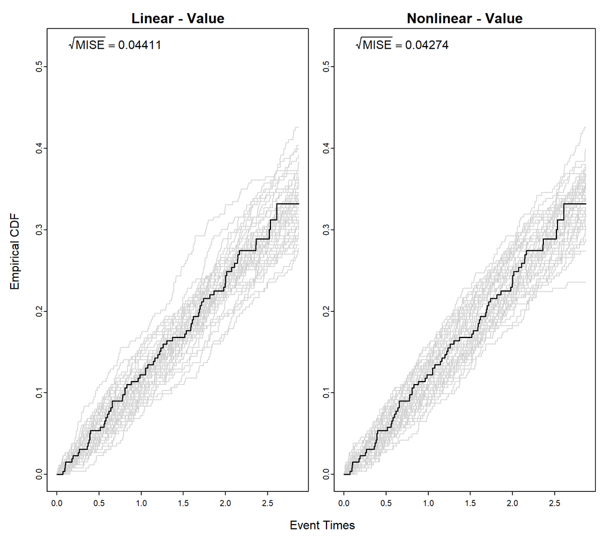

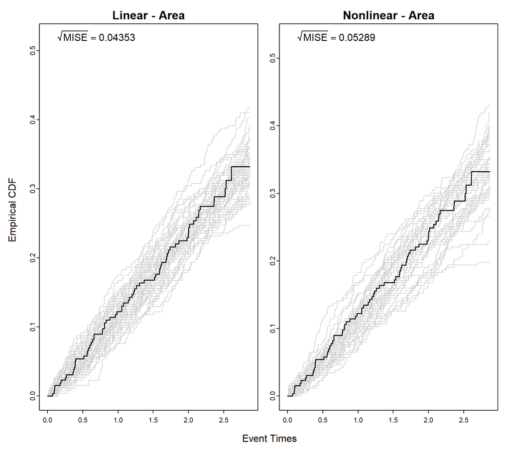

### 1.13.2 Survival Transform to Uniform

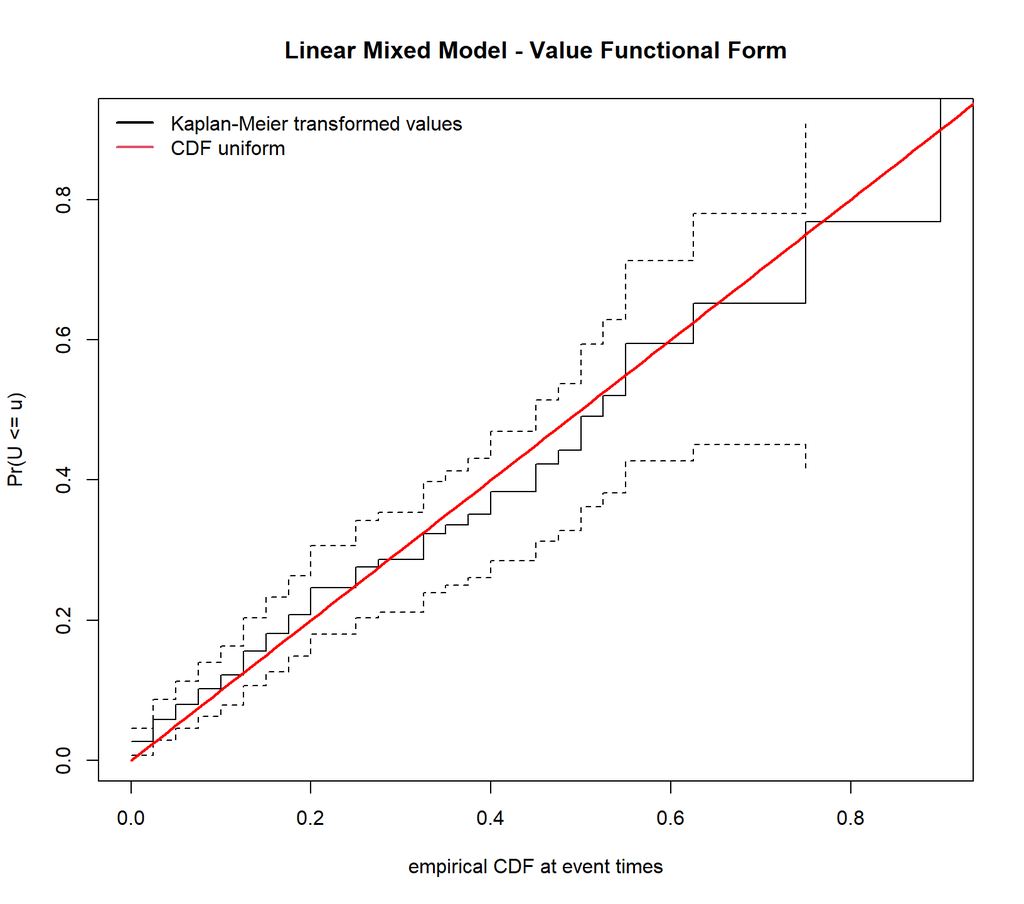

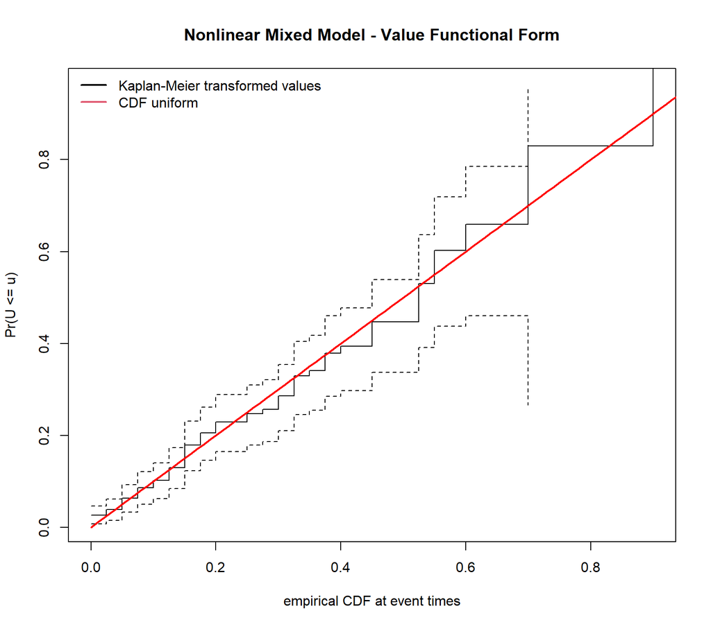

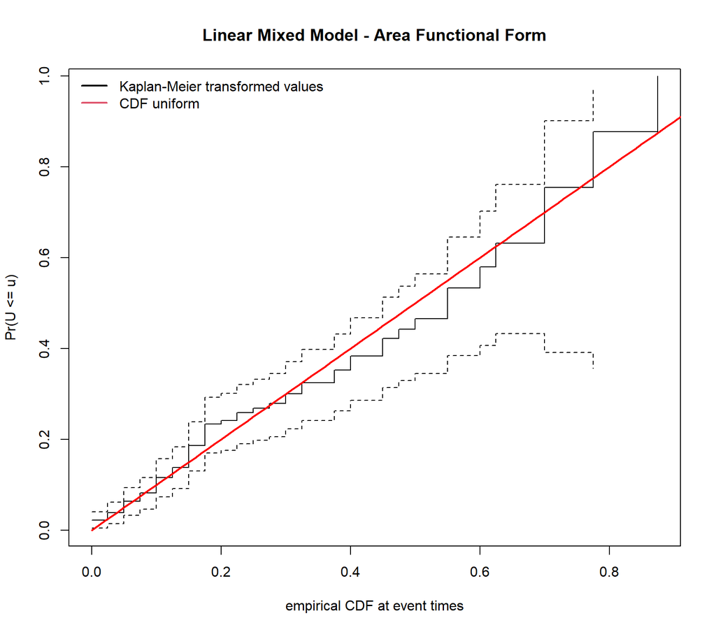

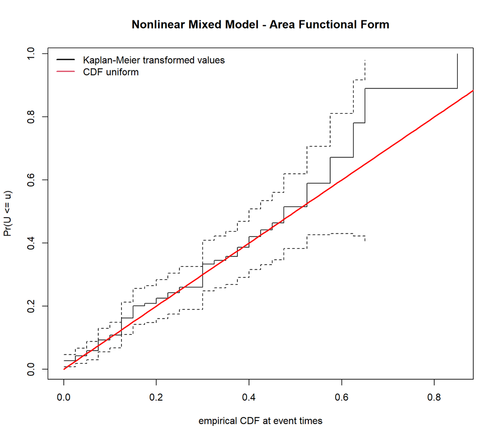

## 1.14 Event Time Model: Posterior-Prior Checks

- The two tabs show the empirical cumulative distribution function and the probability integral transform of the subject-specific cumulative distribution functions for the four fitted joint models.
- In the title of each figure, ‘Linear/Nonlinear’ refers to the specification of the linear mixed models (i.e., linear time trends or splines in both the fixed- and random-effects), and ‘Value/Area’ refers to the functional form (i.e., current value or integral/area).
- In each figure, we compare the observed data metric (black line) with the same metric calculated in 50 simulated datasets from the corresponding model (grey lines).

### 1.14.1 ECDF

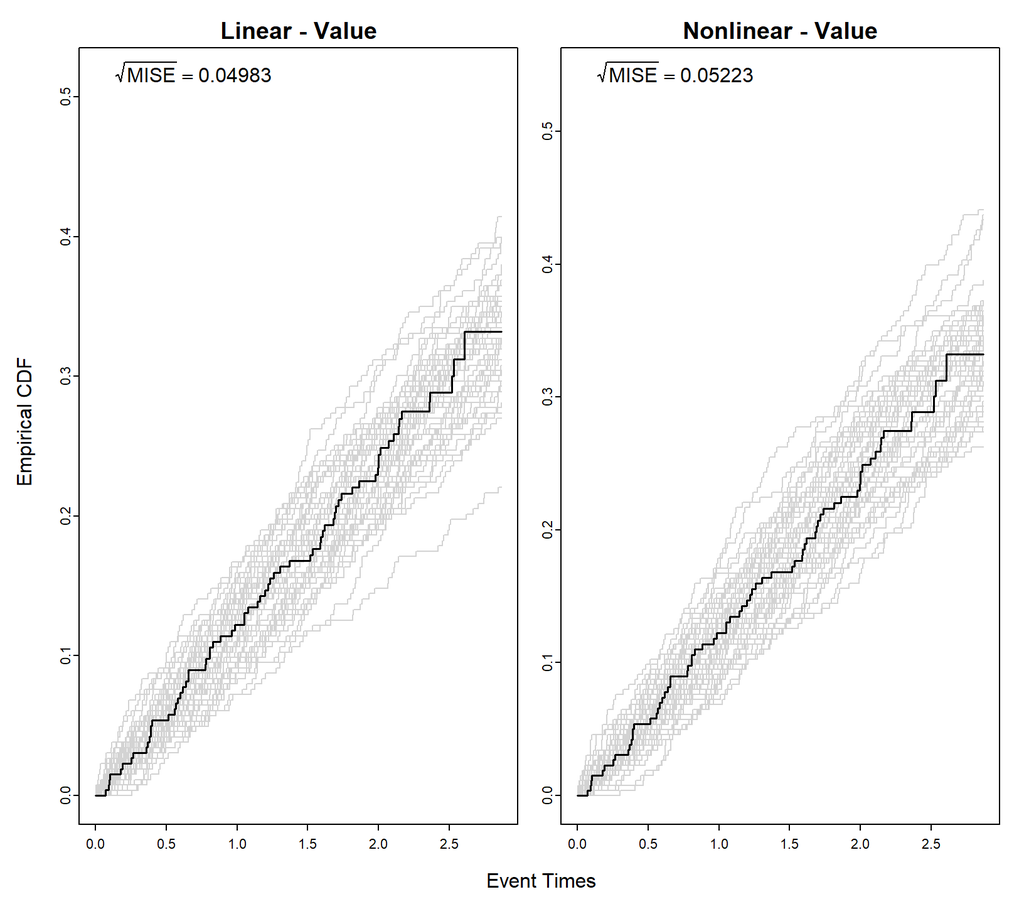

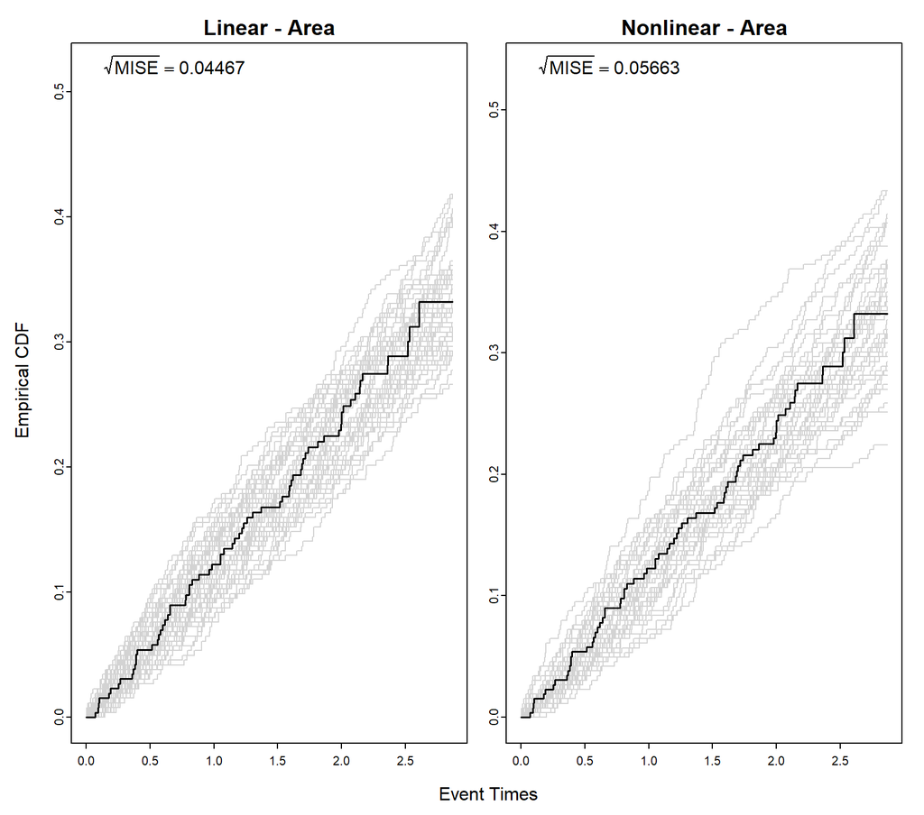

### 1.14.2 Survival Transform to Uniform

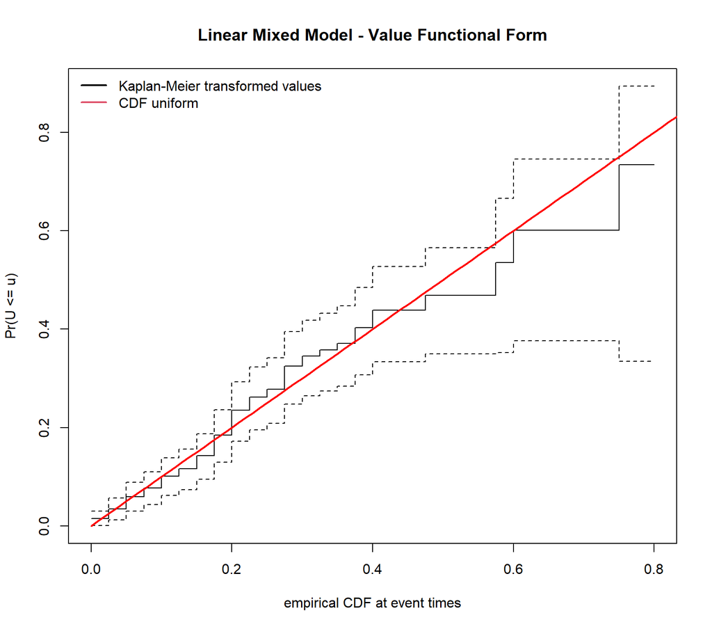

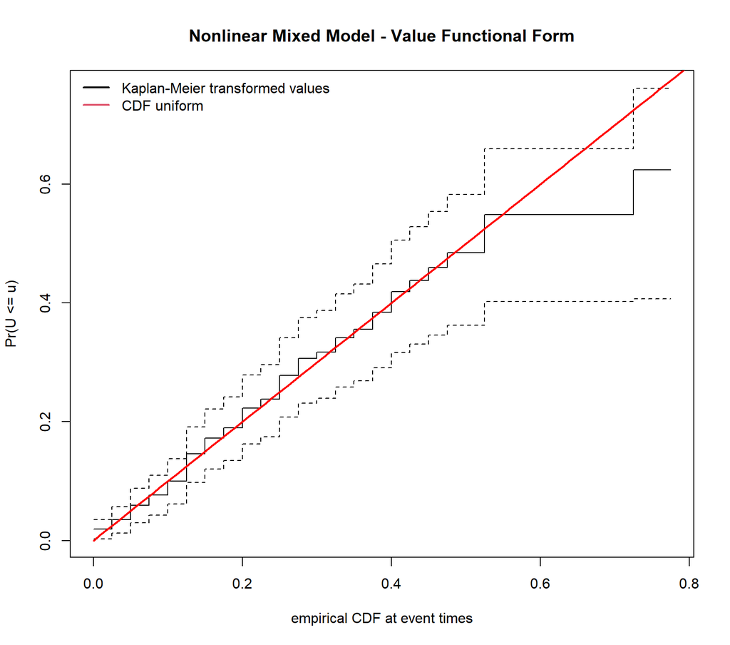

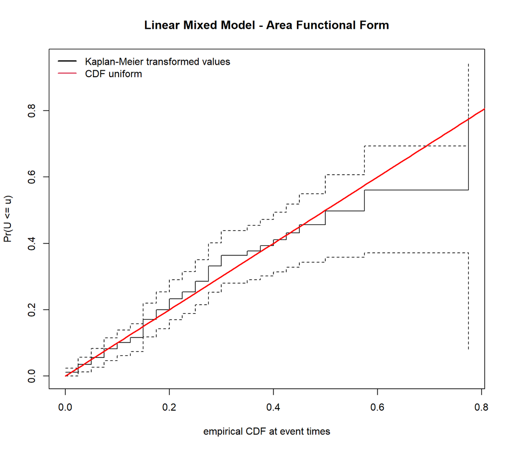

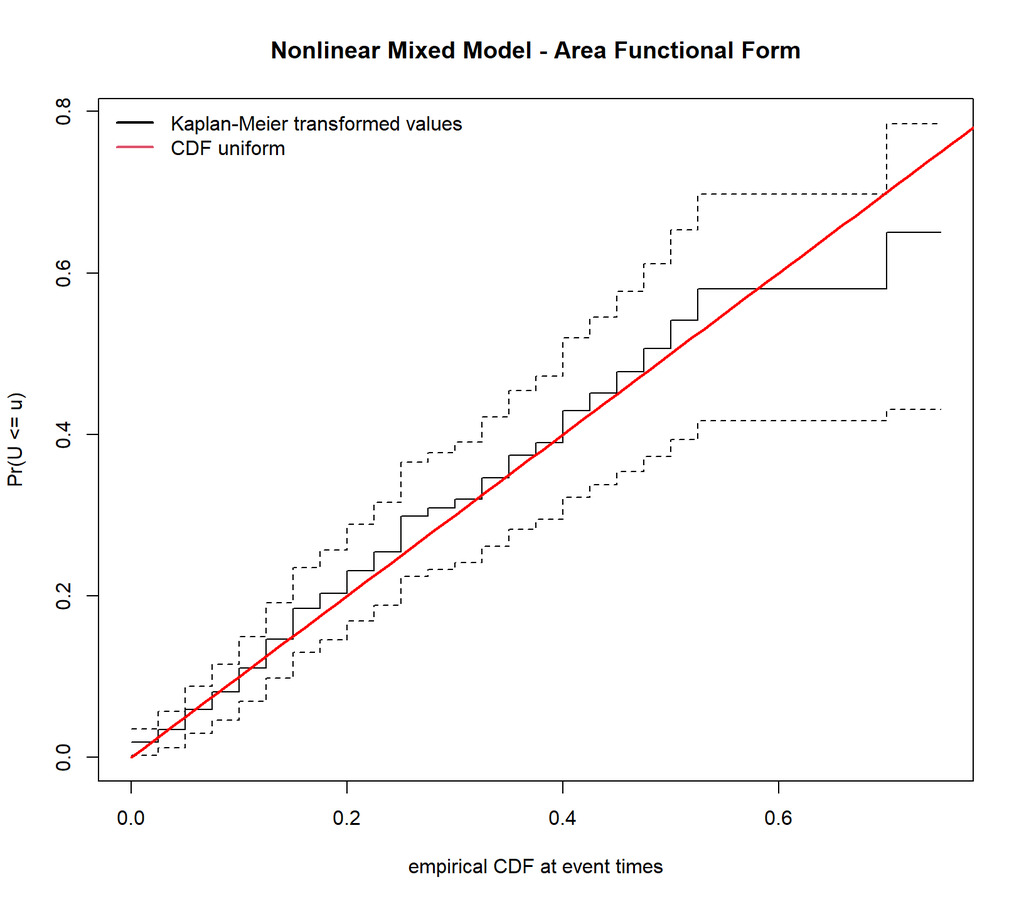

## 1.15 Association: Posterior-Posterior Checks

- The two tabs show the concordance statistic for the two longitudinal outcomes based on the four fitted joint models.
- In the title of each figure, ‘Linear/Nonlinear’ refers to the specification of the linear mixed models (i.e., linear time trends or splines in both the fixed- and random-effects), and ‘Value/Area’ refers to the functional form (i.e., current value or integral/area).
- In each figure, we compare the observed data metric (black line) with the same metric calculated in 50 simulated datasets from the corresponding model (grey lines).

### 1.15.1 eGFR

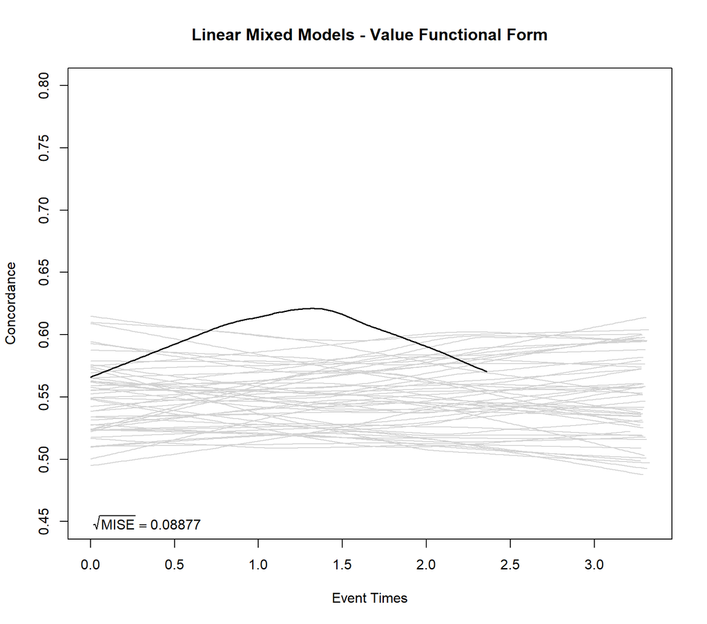

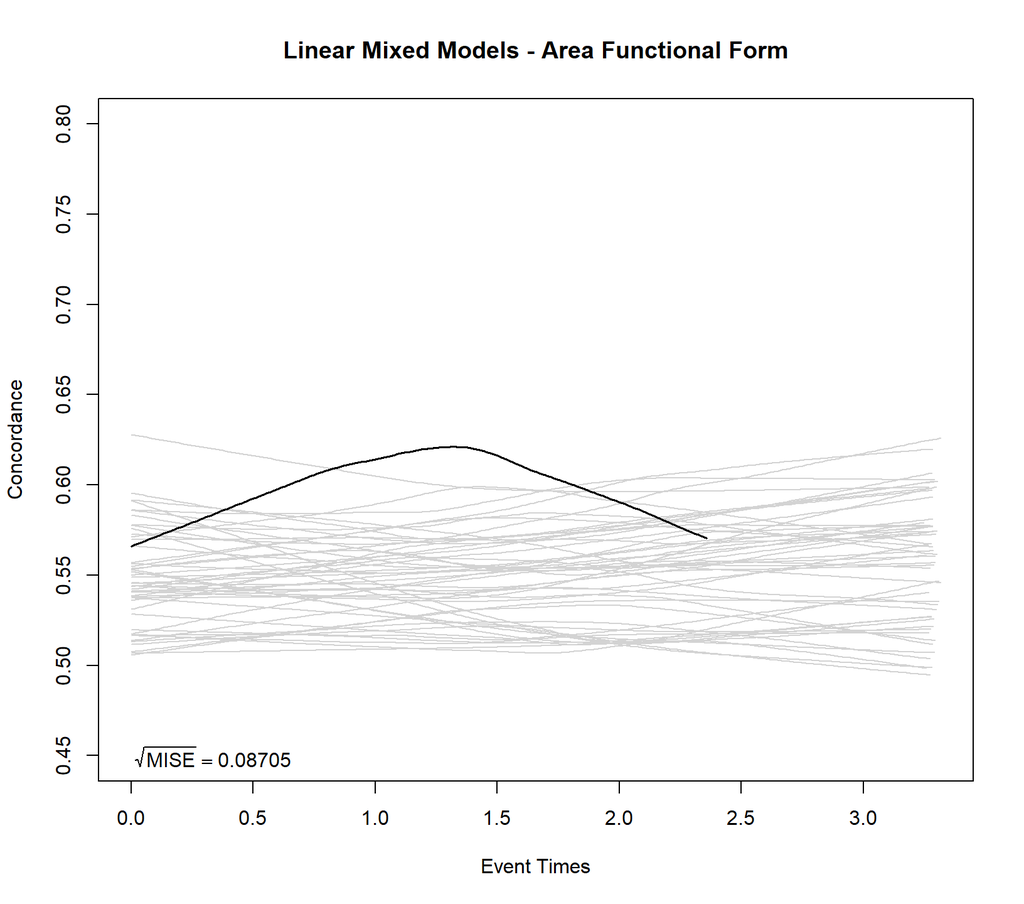

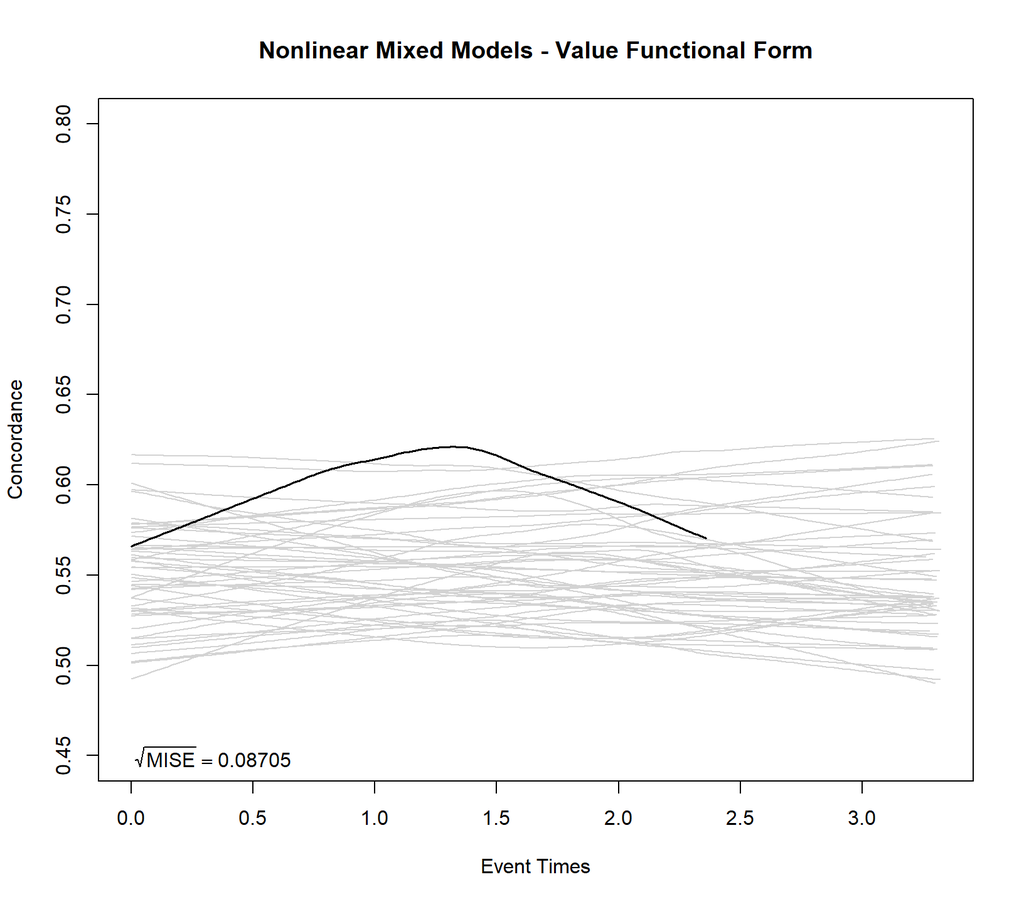

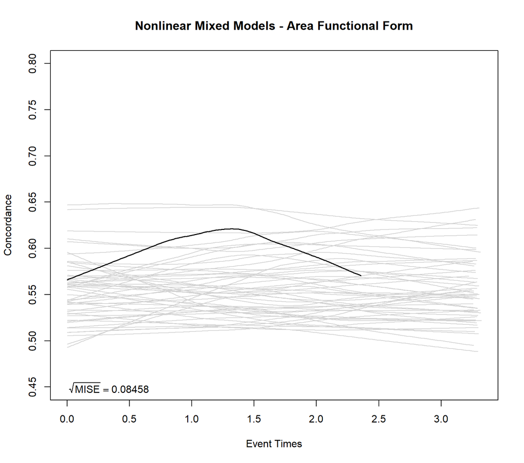

### 1.15.2 NGAL

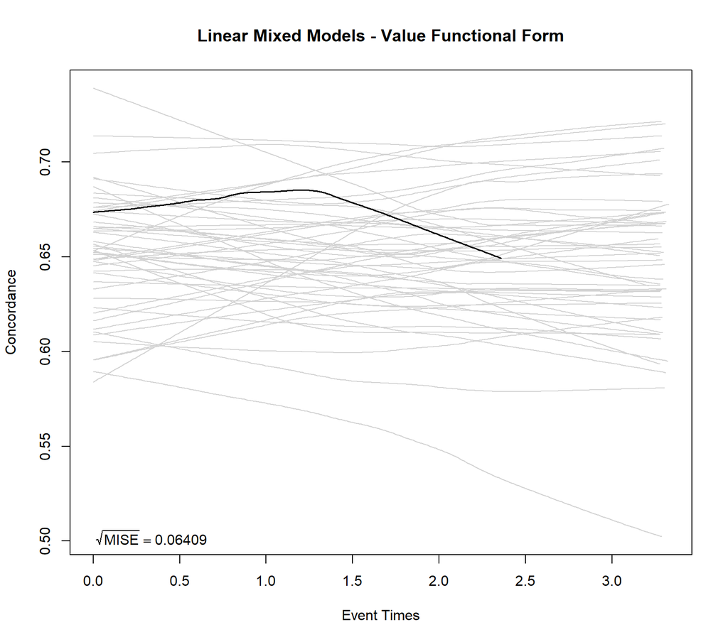

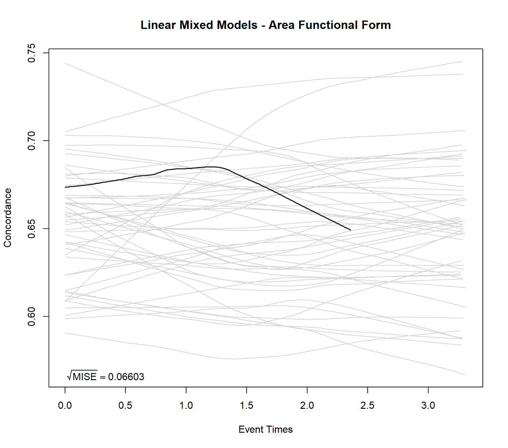

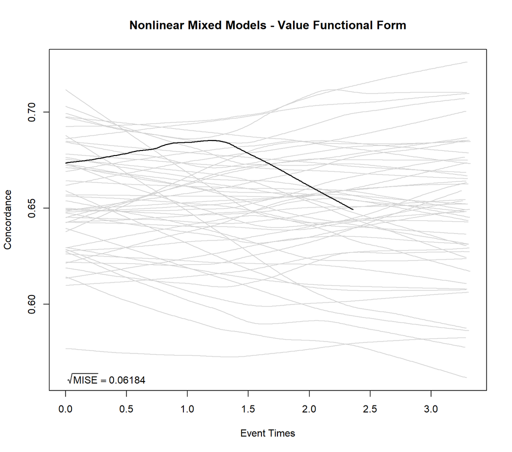

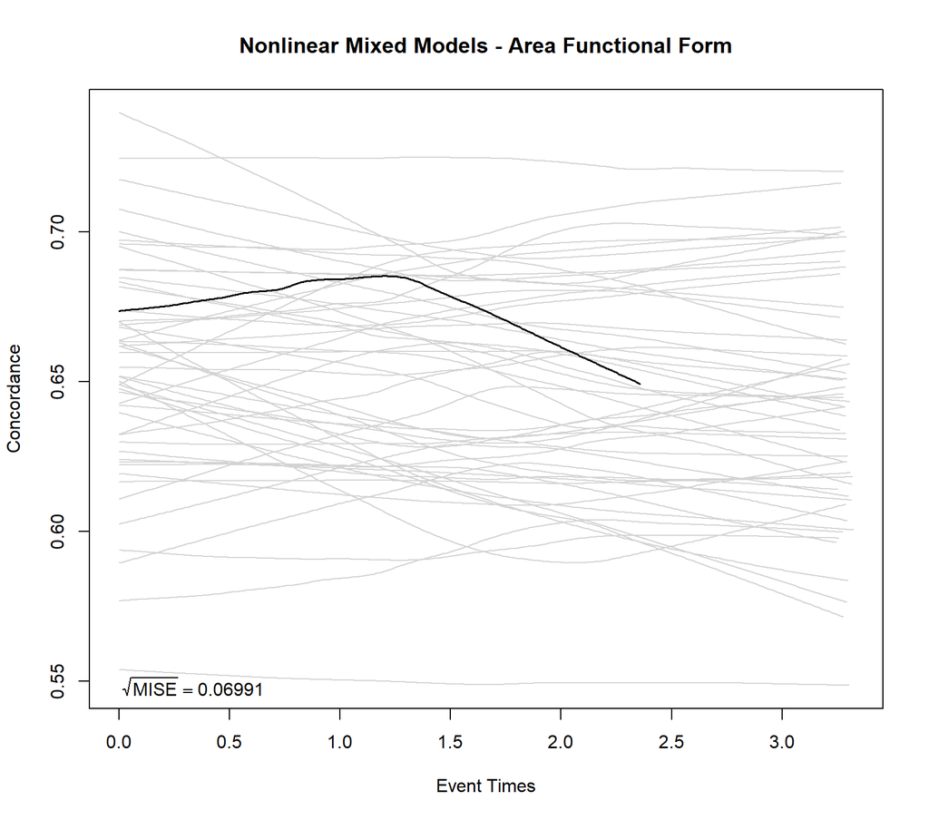

# 2 Simulation

## 2.1 Summary

This section serves as a controlled proof-of-concept to demonstrate how the proposed posterior predictive checks perform when the true data-generating mechanism is known.

## 2.2 Model Comparison

- The four models fitted to the simulated datasets are
  - `jmFit_true`: the true model from which the dataset was simulated.
  - `jmFit_linear`: the joint model with a misspecified the longitudinal submodel by assuming linear subject-specific trends.
  - `jmFit_exp`: the joint model with a misspecified the longitudinal submodel by fitting the mixed model for the outcome variable $y^* = \exp(y)$.
  - `jmFit_slope`: the joint model with a misspecified the survival submodel using the current slope/velocity as the functional form.
- Comparison: The Deviance Information Criterion (DIC), the Watanabe-Akaike information criterion (WAIC), and the log pseudo marginal likelihood (LPML) for the fitted joint models. For DIC and WAIC smaller values are better, whereas for LPML larger values are better.

```
##
##                      DIC      WAIC      LPML
##   jmFit1_slope  2818.188  5997.565 -6506.728
##    jmFit1_true  2815.217  6035.847 -5950.646
##  jmFit1_linear 10680.521 11154.493 -5679.796
##     jmFit1_exp 14727.852 15691.203 -7858.881
##
## The criteria are calculated on the basis of the marginal log-likelihood.
```

```
##
##                      DIC      WAIC      LPML
##    jmFit2_true  3010.890  6694.725 -5374.090
##   jmFit2_slope  3032.507  6772.072 -5739.441
##  jmFit2_linear 10422.728 10480.900 -5251.739
##     jmFit2_exp 17681.645 25554.386 -9979.662
##
## The criteria are calculated on the basis of the marginal log-likelihood.
```

```
##
##                      DIC      WAIC      LPML
##    jmFit3_true  2240.666  4844.627 -5961.789
##   jmFit3_slope  2268.857  5005.813 -5622.762
##  jmFit3_linear 10346.653 10382.342 -5191.319
##     jmFit3_exp 16763.732 26213.332 -9690.560
##
## The criteria are calculated on the basis of the marginal log-likelihood.
```

## 2.3 Longitudinal Model - Simulated Data 1

- The four tabs show the empirical cumulative distribution, mean, variance, and semi-variogram functions for the four fitted joint models.
- In each figure and for the two longitudinal outcomes, we compare the observed data metric (black line) with the same metric calculated in 50 simulated datasets from the corresponding model (grey lines).
- The posterior-posterior checks are shown.

### 2.3.1 ECDF

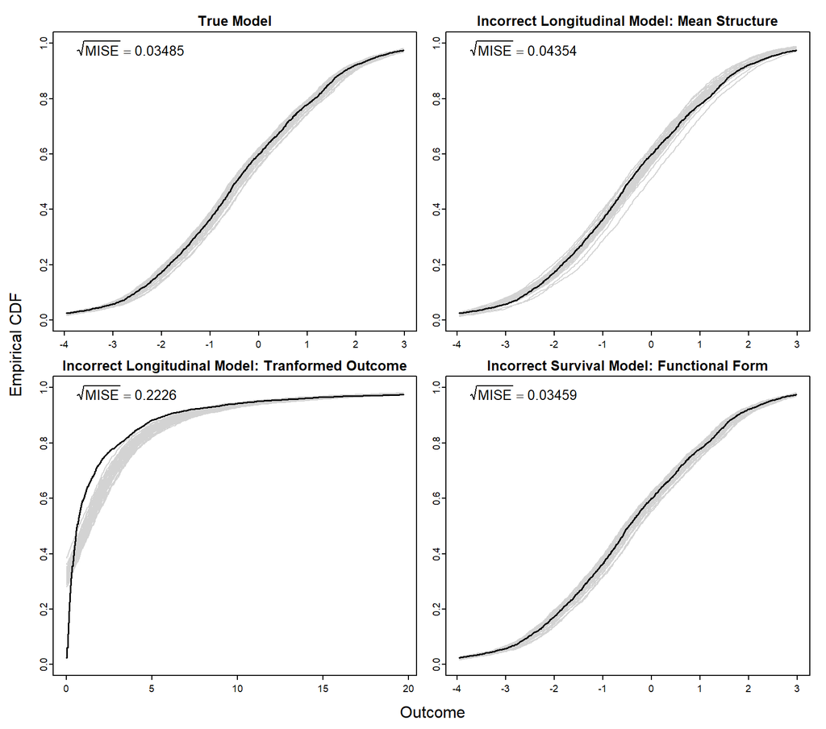

### 2.3.2 Mean Function

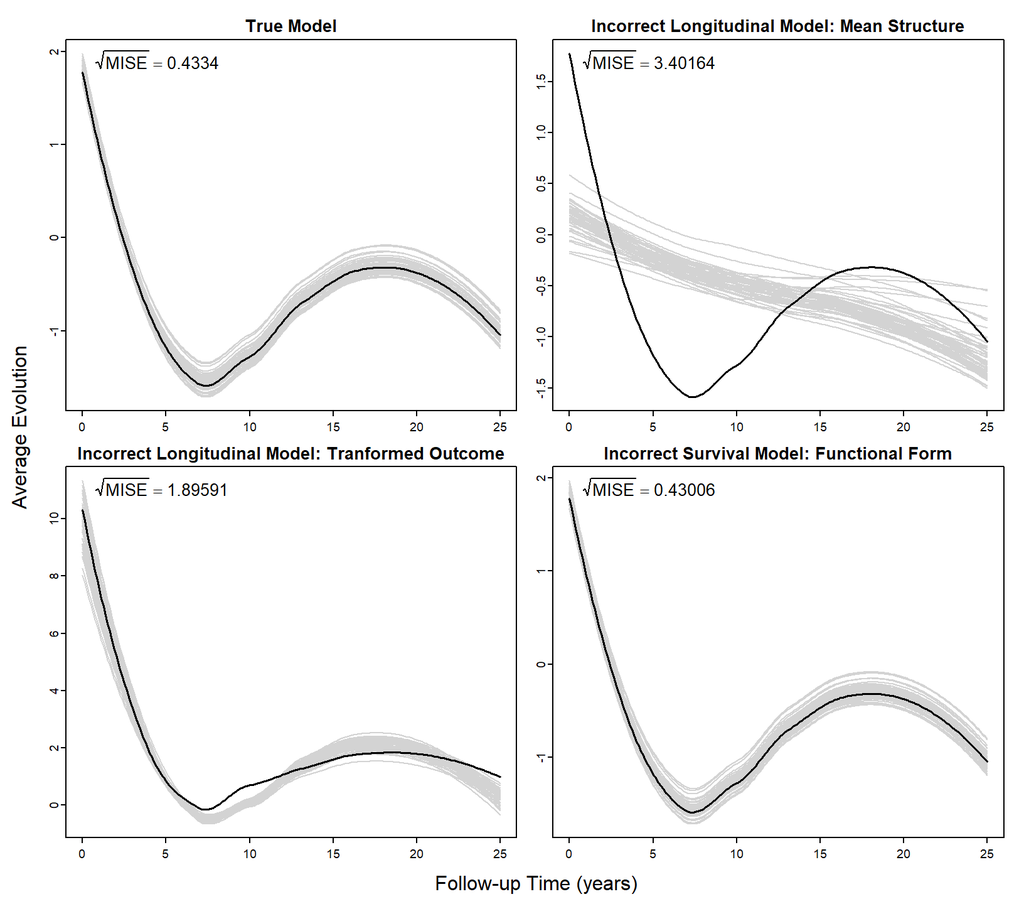

### 2.3.3 Variance Function

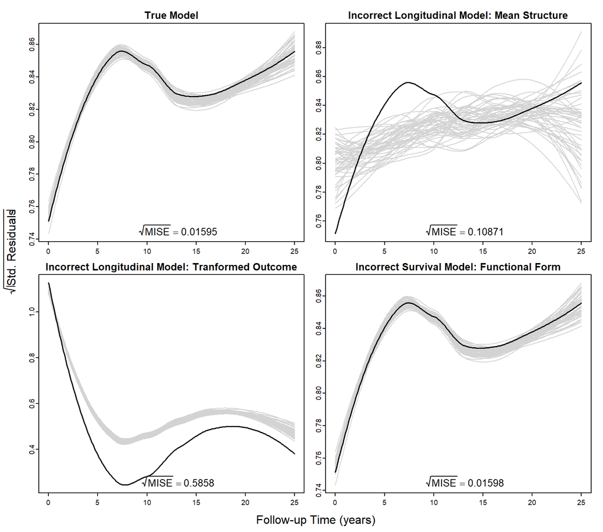

### 2.3.4 Correlation Structure

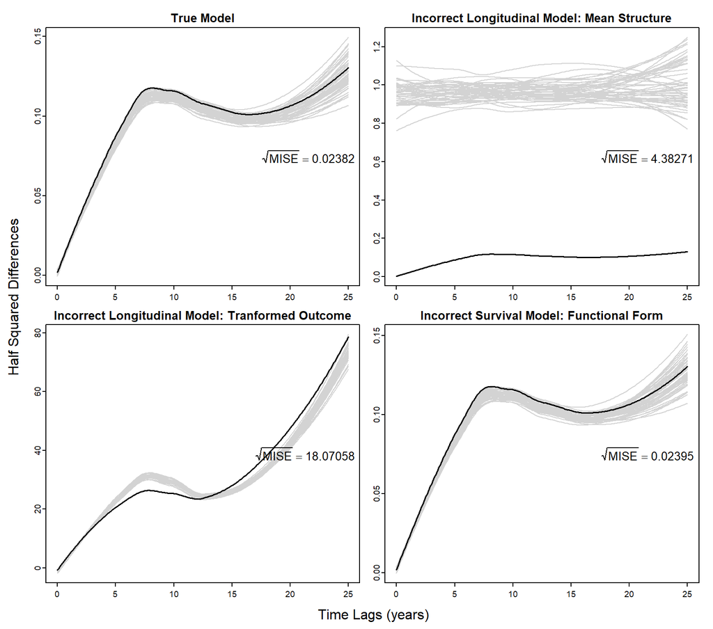

## 2.4 Longitudinal Model - Simulated Data 2

- The four tabs show the empirical cumulative distribution, mean, variance, and semi-variogram functions for the four fitted joint models.
- In each figure and for the two longitudinal outcomes, we compare the observed data metric (black line) with the same metric calculated in 50 simulated datasets from the corresponding model (grey lines).
- The posterior-posterior checks are shown.

### 2.4.1 ECDF

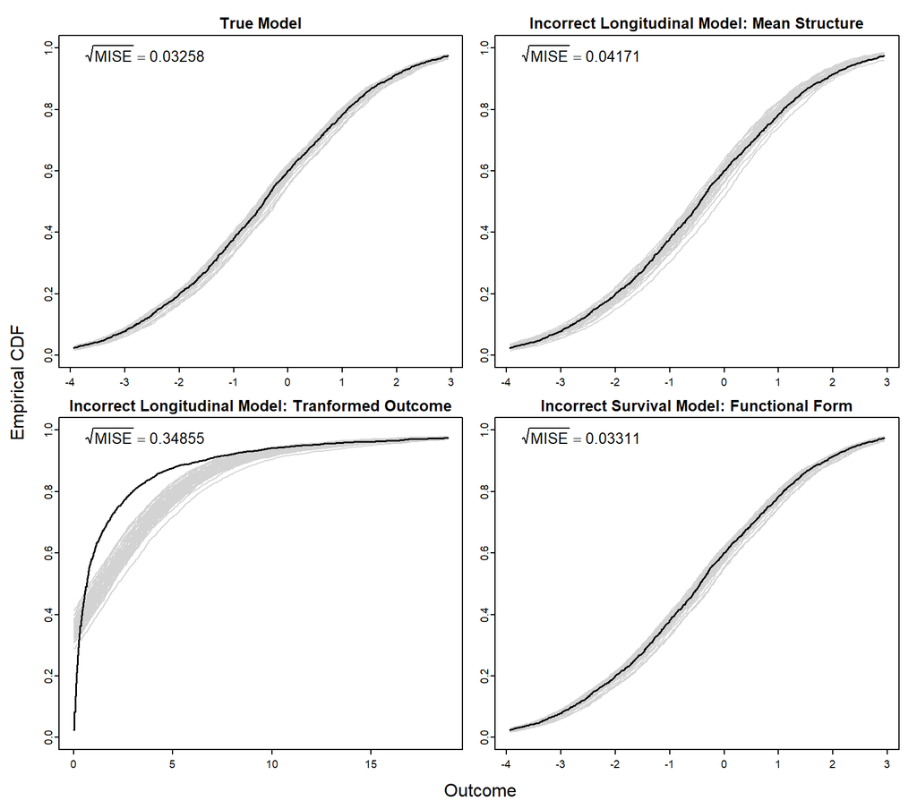

### 2.4.2 Mean Function

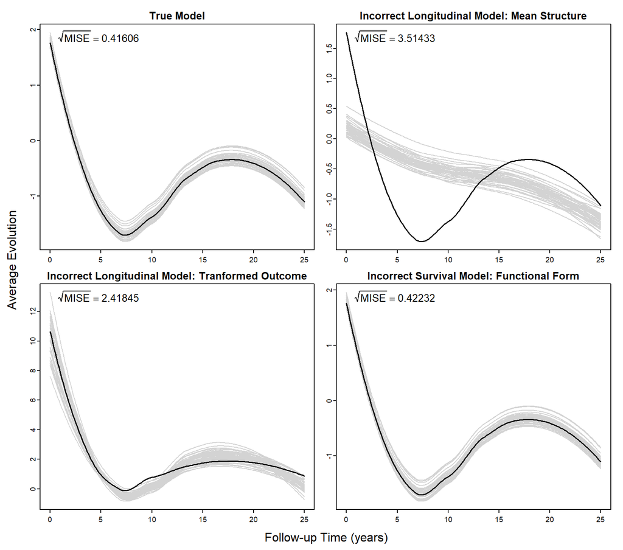

### 2.4.3 Variance Function

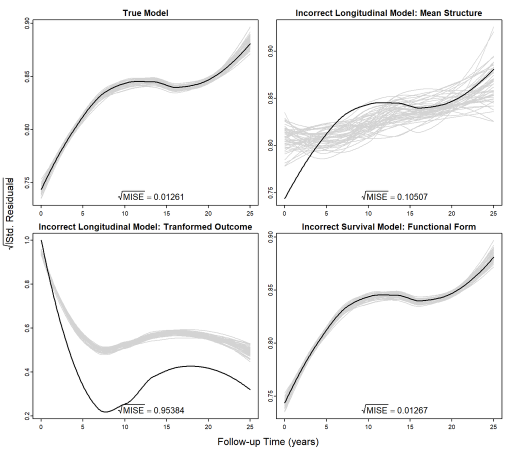

### 2.4.4 Correlation Structure

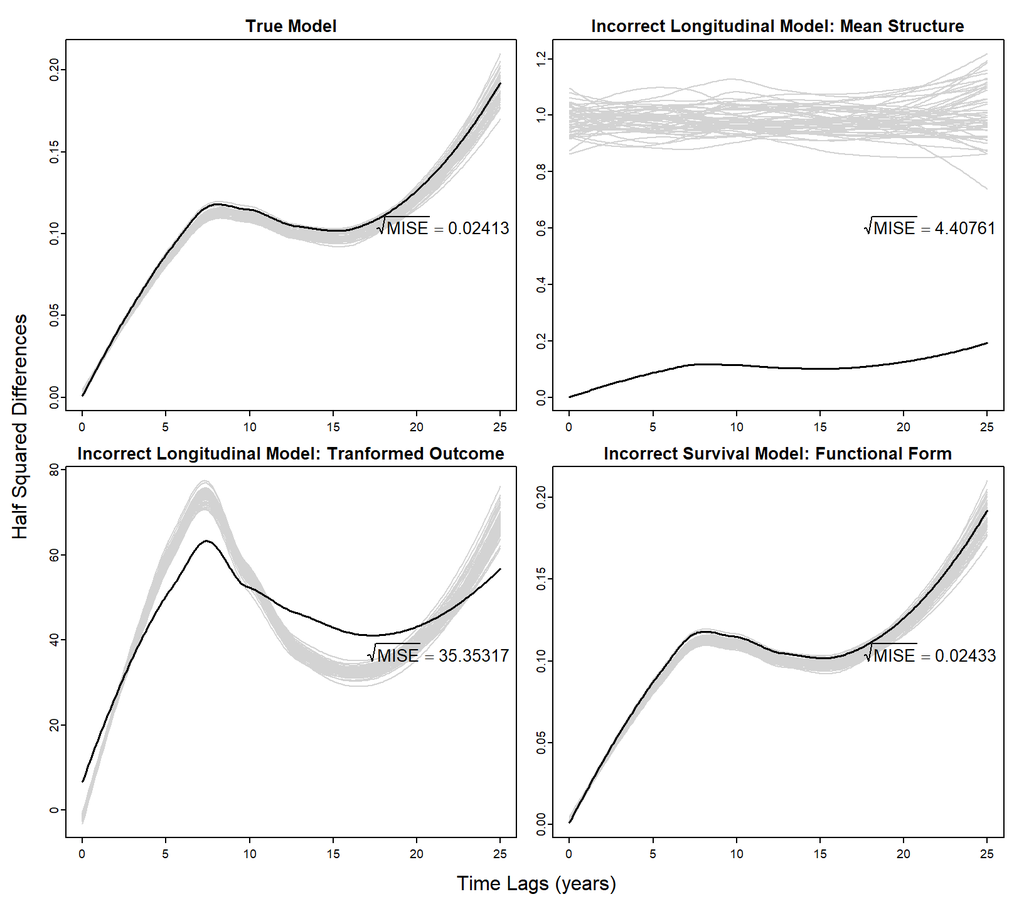

## 2.5 Longitudinal Model - Simulated Data 3

- The four tabs show the empirical cumulative distribution, mean, variance, and semi-variogram functions for the four fitted joint models.
- In each figure and for the two longitudinal outcomes, we compare the observed data metric (black line) with the same metric calculated in 50 simulated datasets from the corresponding model (grey lines).
- The posterior-posterior checks are shown.

### 2.5.1 ECDF

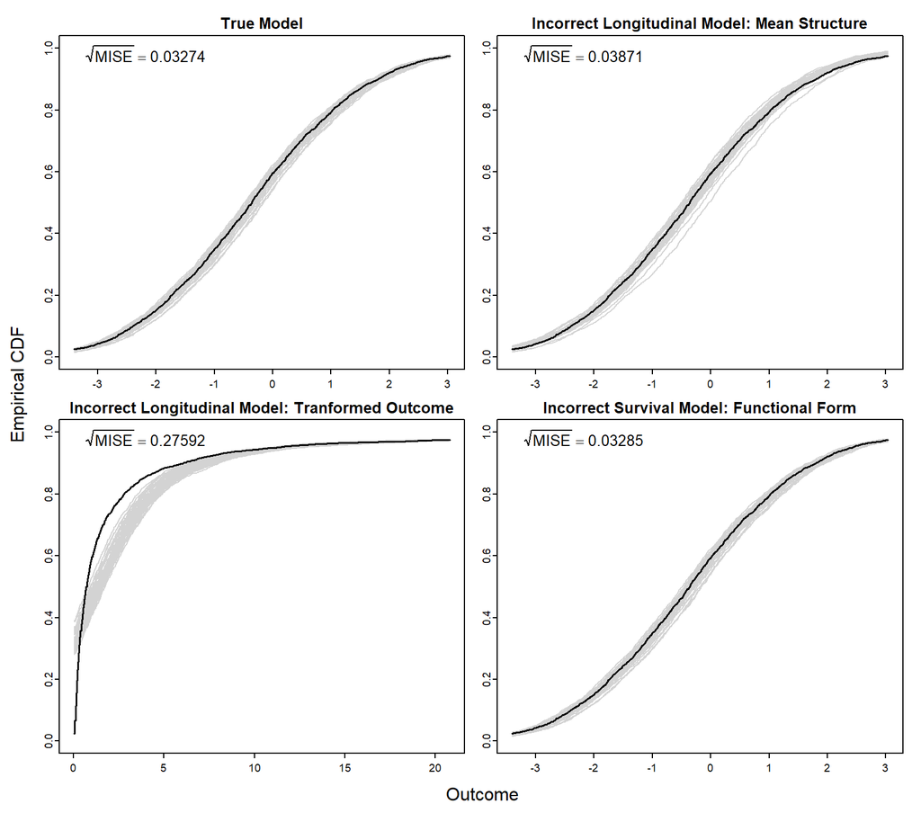

### 2.5.2 Mean Function

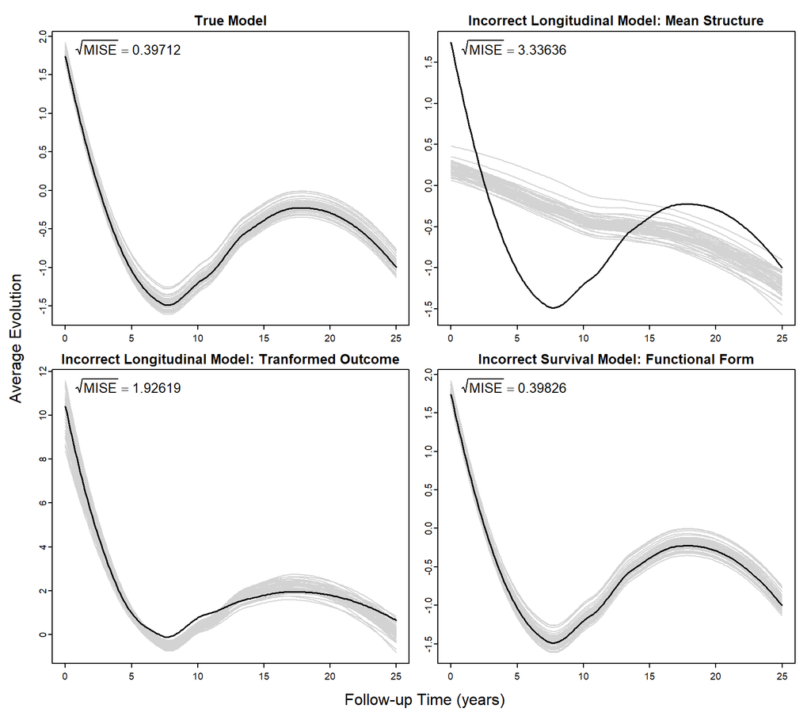

### 2.5.3 Variance Function

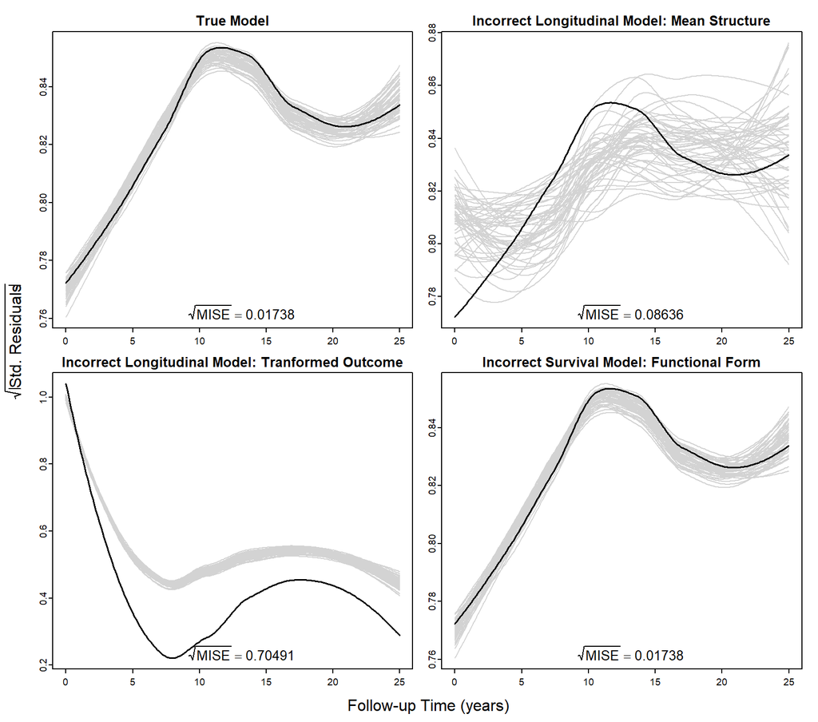

### 2.5.4 Correlation Structure

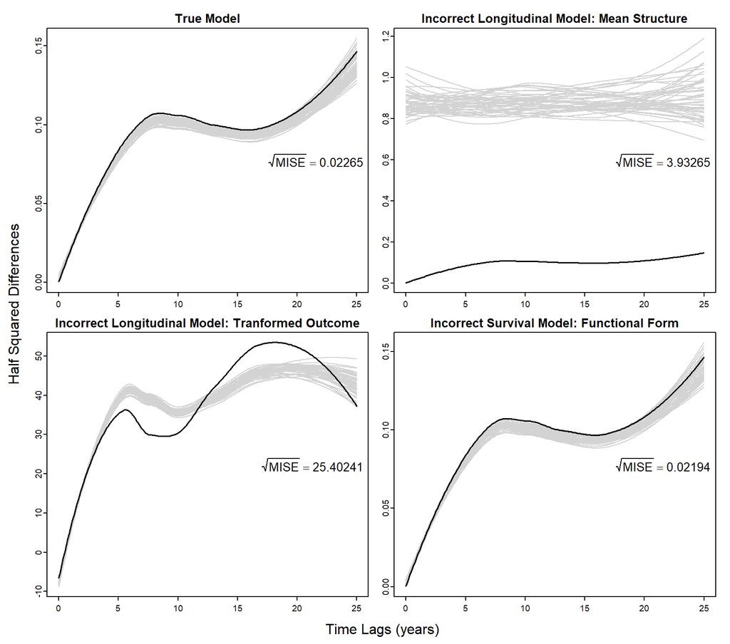

## 2.6 Event Time Model - Simulated Data 1

- The two tabs show the empirical cumulative distribution function and the probability integral transform of the subject-specific cumulative distribution functions for the four fitted joint models.
- In each figure, we compare the observed data metric (black line) with the same metric calculated in 50 simulated datasets from the corresponding model (grey lines).
- The posterior-posterior checks are shown.

### 2.6.1 ECDF

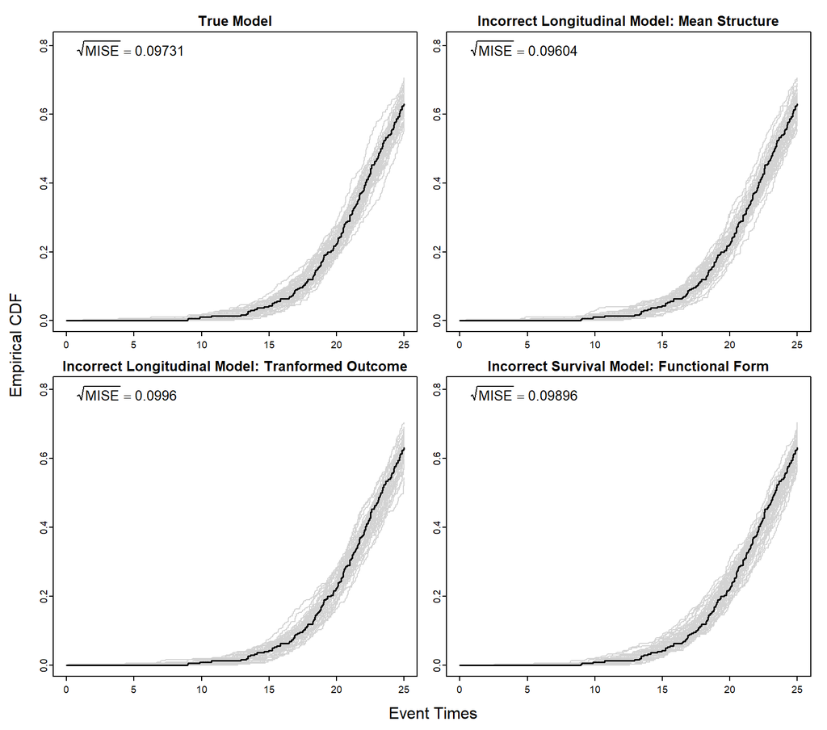

### 2.6.2 Survival Transform to Uniform

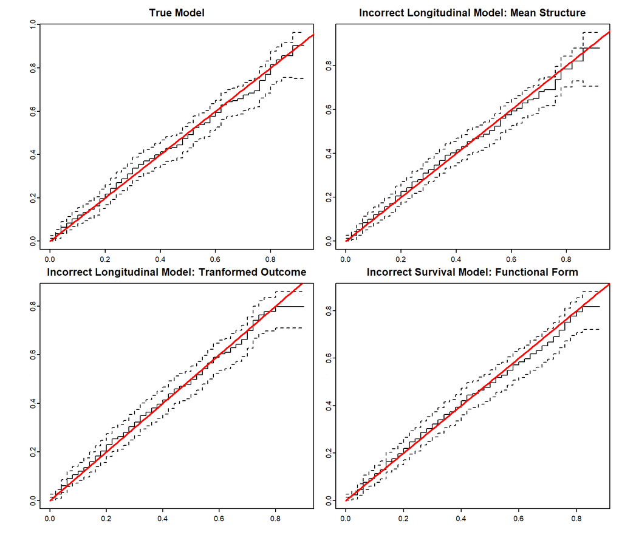

## 2.7 Event Time Model - Simulated Data 2

- The two tabs show the empirical cumulative distribution function and the probability integral transform of the subject-specific cumulative distribution functions for the four fitted joint models.
- In each figure, we compare the observed data metric (black line) with the same metric calculated in 50 simulated datasets from the corresponding model (grey lines).
- The posterior-posterior checks are shown.

### 2.7.1 ECDF

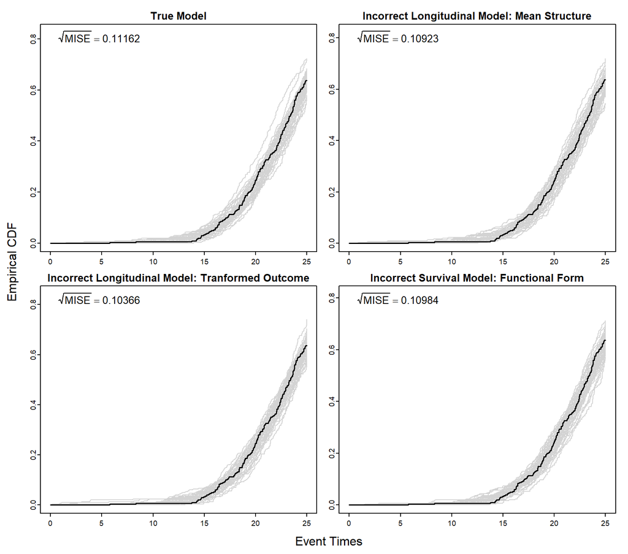

### 2.7.2 Survival Transform to Uniform

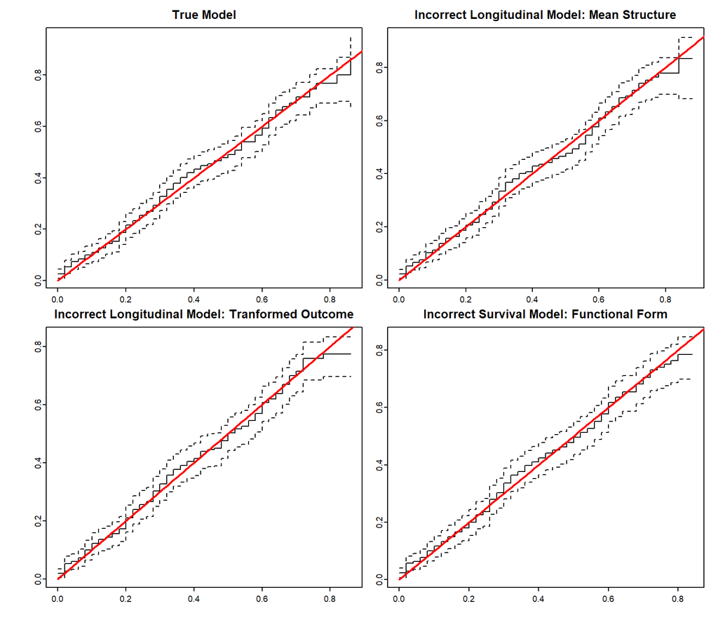

## 2.8 Event Time Model - Simulated Data 3

- The two tabs show the empirical cumulative distribution function and the probability integral transform of the subject-specific cumulative distribution functions for the four fitted joint models.
- In each figure, we compare the observed data metric (black line) with the same metric calculated in 50 simulated datasets from the corresponding model (grey lines).
- The posterior-posterior checks are shown.

### 2.8.1 ECDF

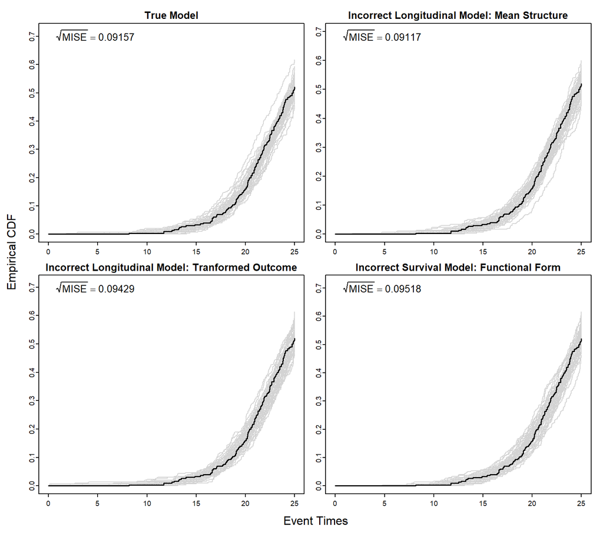

### 2.8.2 Survival Transform to Uniform

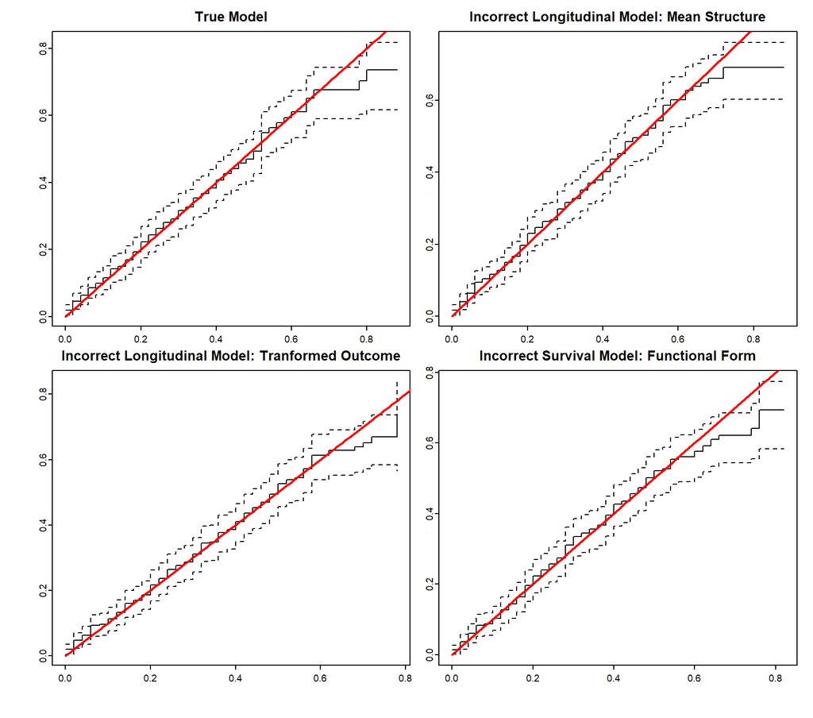

## 2.9 Association - Simulated Data 1

- The concordance statistic for the four fitted joint models.
- In each figure, we compare the observed data metric (black line) with the same metric calculated in 50 simulated datasets from the corresponding model (grey lines).
- The posterior-posterior checks are shown.

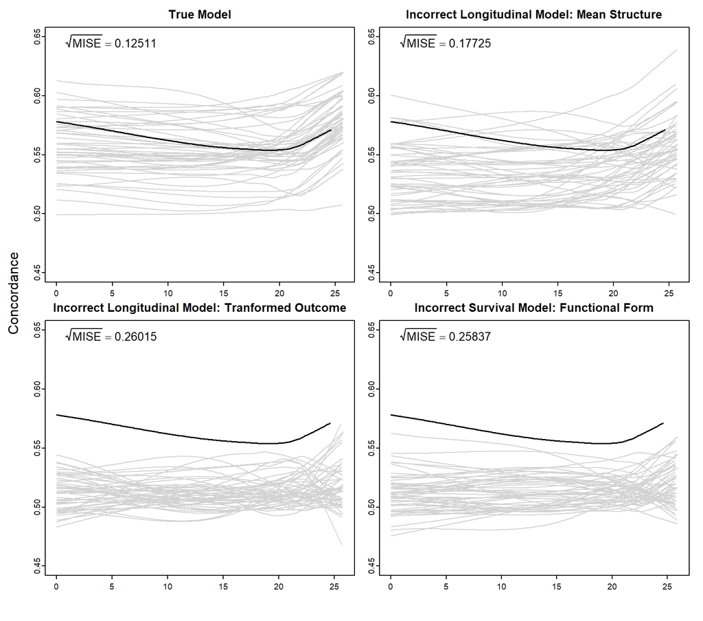

## 2.10 Association - Simulated Data 2

- The concordance statistic for the four fitted joint models.
- In each figure, we compare the observed data metric (black line) with the same metric calculated in 50 simulated datasets from the corresponding model (grey lines).
- The posterior-posterior checks are shown.

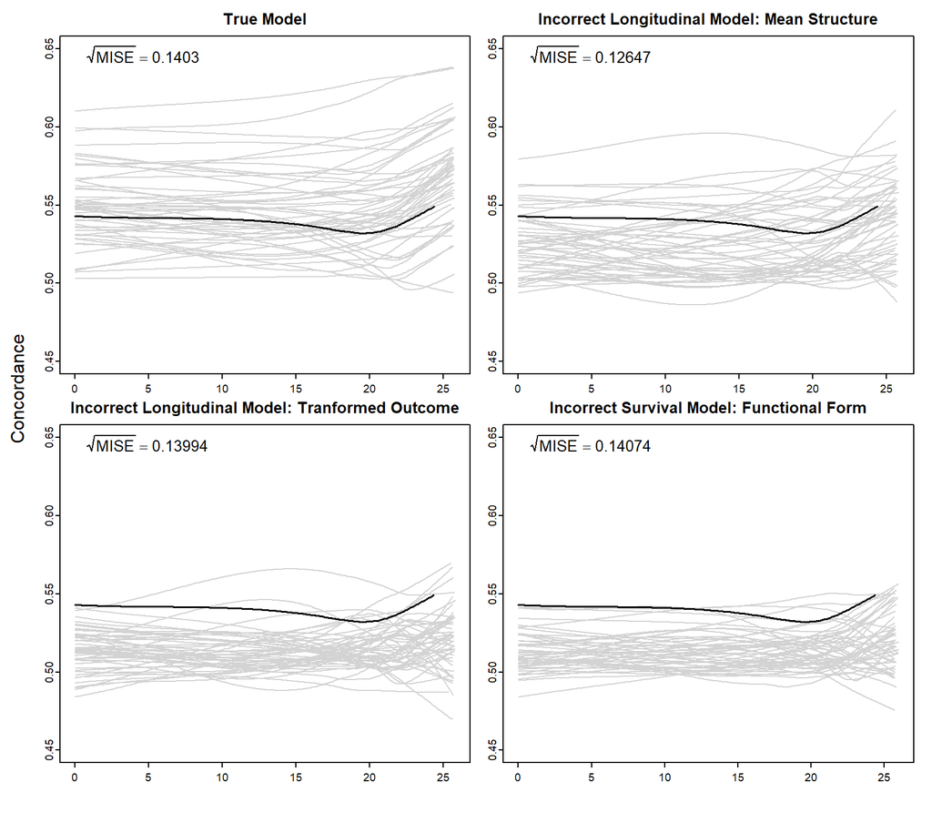

## 2.11 Association - Simulated Data 3

- The concordance statistic for the four fitted joint models.
- In each figure, we compare the observed data metric (black line) with the same metric calculated in 50 simulated datasets from the corresponding model (grey lines).
- The posterior-posterior checks are shown.

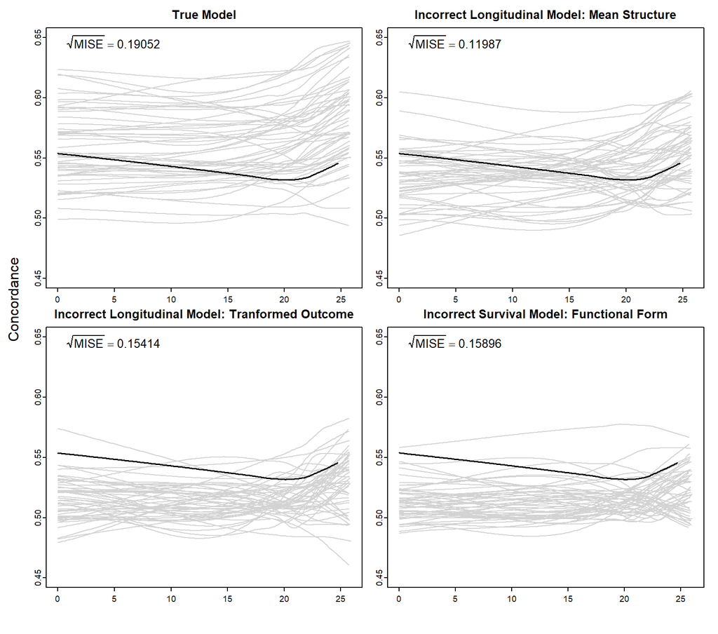